# 225612018_web_scrapping2

This scenario is inspired by Future Today Institute which provide leading strategic foresight and management consultant by applying data driven applied research to reveals trends and calculate how they will distrupt business, government, and society.

As a junior consultant in FTI, I was given tasks to create blog content that alligned with today’s trend in Artificial Intelligence field. In regards with my ignorance in this topic, i was thinking from where d I start? what topic should i studied and cover in the articles?

After thinking it thoroughtly, I decide to create articles from the negative side artificial intelligence that mostly being speak of, from the sub topic that mostly appear in artificial intelligence.

With that in mind, I have set the step as described below:

1. Find relevant news website that available to scrape and providing AI news
2. Scrapping the title from articles for the past one year
3. Text mining on news title
4. Sentiment analysis
1. Using bing lexicon
2. Using nrc lexicon
3. Using afinn lexicon
4. Compare all lexicon
5. Create visualization
- Bar chart
- Word Cloud

## 1. Find relevant news website that available to scrape and providing AI news

Check whether we can scrape this website

```r
paths_allowed(
  paths =c("https://venturebeat.com/category/ai/page/1/")
)
```

```
##
 venturebeat.com
```

```
## [1] TRUE
```

this website allow scrapping

```r
scrape_news_ai = function(x) {
  GET(x, add_headers("user-agent"="Hi, I am randi. I had college week assignment to do web scraping and interested to use VentureBeat data for creating text-mining analysis, this is just for the college task only and i consent to not share it outside this scope, please get in touch with me in ([[randi.eka1301@gmail.com]])"))%>%
  read_html(x)%>%
  {tibble(
    title = html_nodes(., ".ArticleListing__title-link")%>%
      html_text(),
    date = html_nodes(., ".ArticleListing__time")%>%
      html_text()
  )}%>%
    mutate(title = make_clean_names(title, sep_out = " "))
}
```

### Create iteration for web scraping

Create multiple link for iteration

```r
news_urls = paste0("https://venturebeat.com/category/ai/page/", seq_len(40))
```

Scrape all data

```r
news_raw = future_map_dfr(news_urls, possibly(scrape_news_ai, otherwise = NULL), .progress=TRUE)
```

Transform string to date format

```r
news_proc = news_raw%>%
  mutate(date=lubridate::mdy_hm(date))%>%
  glimpse()
```

```
## Rows: 1,558
## Columns: 2
## $ title <chr> "intel researchers see a path to trillion transistor chips by 20…
## $ date  <dttm> 2022-12-03 12:00:00, 2022-12-03 11:10:00, 2022-12-03 08:20:00, …
```

```r
#head(news_proc)
```

### Parsing Title to WOrds

Parse title to words

```r
news_clean = news_proc %>%
  dplyr::select(title) %>%
  unnest_tokens(word, title)

tail(news_clean, n=20)
```

```
## # A tibble: 20 × 1
##    word
##    <chr>
##  1 pharma
##  2 startup
##  3 quris
##  4 aims
##  5 to
##  6 use
##  7 a
##  8 patient
##  9 on
## 10 a
## 11 chip
## 12 to
## 13 target
## 14 drug
## 15 delivery
## 16 ai
## 17 technology
## 18 modernizes
## 19 warehouse
## 20 management
```

Parsing data visualization

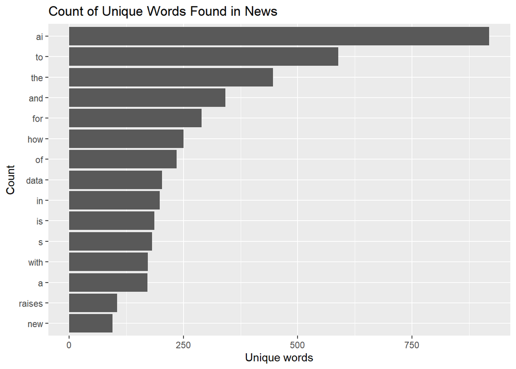

```r
news_clean %>%
  count(word, sort=TRUE) %>%
  top_n(15)%>%
  mutate(word=reorder(word,n))%>%
  ggplot(aes(x=word, y=n))+geom_col()+xlab(NULL)+coord_flip()+labs(x="Count",y="Unique words",title="Count of Unique Words Found in News")
```

### Stop Word Removal

Meaning of lexicon: https://www.vocabulary.com/dictionary/lexicon Lexicon contained in this dataset: https://juliasilge.github.io/tidytext/reference/stop_words.html

```r
data("stop_words")

head(stop_words)
```

```
## # A tibble: 6 × 2
##   word      lexicon
##   <chr>     <chr>
## 1 a         SMART
## 2 a's       SMART
## 3 able      SMART
## 4 about     SMART
## 5 above     SMART
## 6 according SMART
```

```r
nrow(news_clean)
```

```
## [1] 16414
```

```r
cleaned_news_words = news_clean %>%
  anti_join(stop_words) # is antijoin function is to eliminate similar data between 2 dataset?
nrow(cleaned_news_words)
```

```
## [1] 10850
```

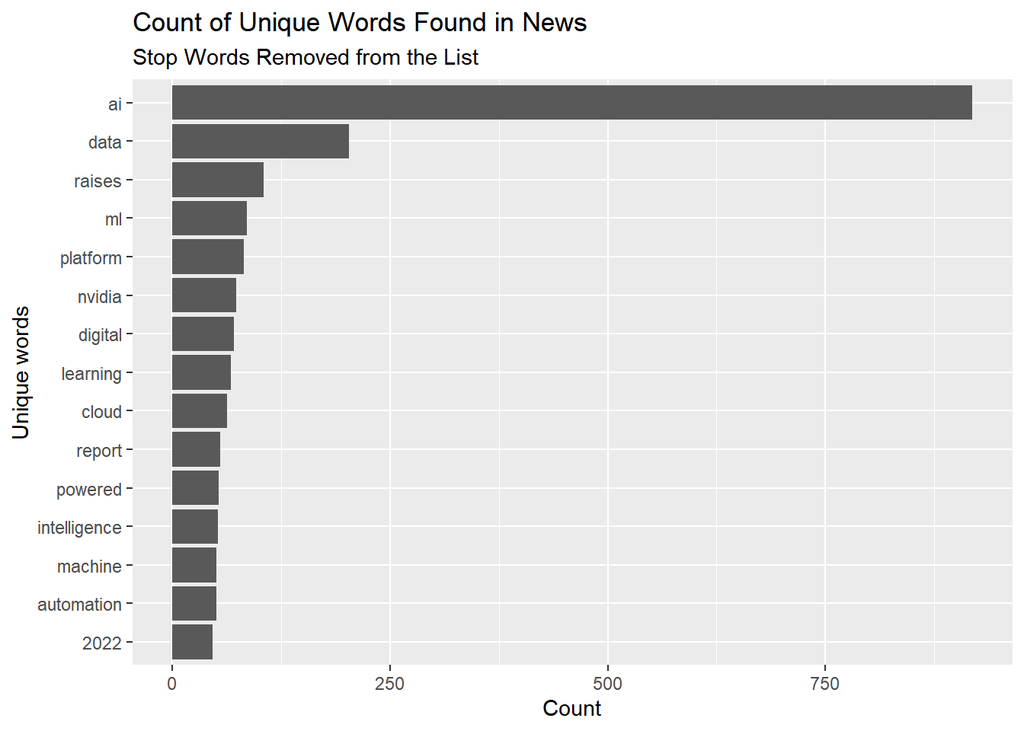

```r
cleaned_news_words %>%
  count(word, sort=TRUE) %>%
  top_n(15)%>%
  mutate(word=reorder(word,n))%>%
  ggplot(aes(x=word,y=n))+
  geom_col()+
  xlab(NULL)+
  coord_flip()+
  labs(y="Count",x="Unique words",
       title="Count of Unique Words Found in News",
       subtitle="Stop Words Removed from the List")
```

### N-Gramming

```r
#install.packages("widyr")
library(widyr)
news_paired_words = news_proc %>%
  dplyr::select(title)%>%
  unnest_tokens(paired_words, title,token="ngrams",n=2)

news_paired_words%>%
  count(paired_words, sort=TRUE)
```

```
## # A tibble: 10,592 × 2
##    paired_words         n
##    <chr>            <int>
##  1 how ai              59
##  2 ai and              56
##  3 ai to               51
##  4 ai powered          47
##  5 machine learning    43
##  6 ai is               42
##  7 how to              34
##  8 in the              34
##  9 of ai               34
## 10 digital twins       33
## # … with 10,582 more rows
```

```r
news_separated_words <- news_paired_words %>%
  tidyr::separate(paired_words,c("word1","word2"),sep=" ")

news_filtered <- news_separated_words  %>%
  filter(!word1%in%stop_words$word) %>%
  filter(!word2%in%stop_words$word)

news_counts <- news_filtered  %>%
  count(word1,word2,sort=TRUE)

head(news_separated_words)
```

```
## # A tibble: 6 × 2
##   word1       word2
##   <chr>       <chr>
## 1 intel       researchers
## 2 researchers see
## 3 see         a
## 4 a           path
## 5 path        to
## 6 to          trillion
```

Word network visualization

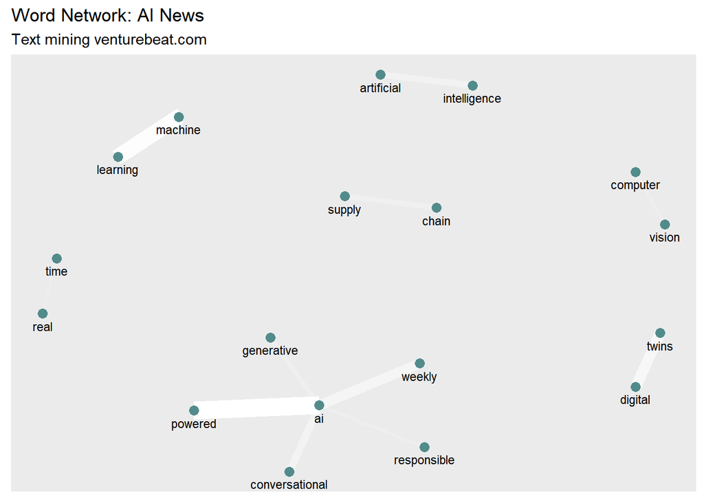

```r
news_counts  %>%
  filter(n>=15) %>%
  graph_from_data_frame() %>%
  ggraph(layout="fr") +
  geom_edge_link(aes(width = n, edge_alpha = n), show.legend = FALSE,edge_colour = "white")+
  geom_node_point(color="darkslategray4",size=3)+
  geom_node_text(aes(label=name),vjust=1.8,size=3)+
  labs(title="Word Network: AI News",
  subtitle="Text mining venturebeat.com",
  x="",y="")
```

From here, there are several interesting topic to cover based on the frequencies

1. Digital twin, supply chain
2. AI powered
3. Conversational AI
4. Computer Vision
5. Generative AI

This 5 topics are consider interesting to reader since the frequencies of appearance is more than 15. Next, lets going into sentiment analysis to find the negative term to be paired with the topics above

## Sentiment Analysis

```r
library(tidytext)
#install.packages("textdata")

get_sentiments("afinn")
```

```
## # A tibble: 2,477 × 2
##    word       value
##    <chr>      <dbl>
##  1 abandon       -2
##  2 abandoned     -2
##  3 abandons      -2
##  4 abducted      -2
##  5 abduction     -2
##  6 abductions    -2
##  7 abhor         -3
##  8 abhorred      -3
##  9 abhorrent     -3
## 10 abhors        -3
## # … with 2,467 more rows
```

```r
get_sentiments("bing")
```

```
## # A tibble: 6,786 × 2
##    word        sentiment
##    <chr>       <chr>
##  1 2-faces     negative
##  2 abnormal    negative
##  3 abolish     negative
##  4 abominable  negative
##  5 abominably  negative
##  6 abominate   negative
##  7 abomination negative
##  8 abort       negative
##  9 aborted     negative
## 10 aborts      negative
## # … with 6,776 more rows
```

```r
get_sentiments("nrc")
```

```
## # A tibble: 13,872 × 2
##    word        sentiment
##    <chr>       <chr>
##  1 abacus      trust
##  2 abandon     fear
##  3 abandon     negative
##  4 abandon     sadness
##  5 abandoned   anger
##  6 abandoned   fear
##  7 abandoned   negative
##  8 abandoned   sadness
##  9 abandonment anger
## 10 abandonment fear
## # … with 13,862 more rows
```

```r
news_clean_s = news_proc %>%
  dplyr::select(title) %>%
  unnest_tokens(word, title)

tail(news_clean_s, n=20)
```

```
## # A tibble: 20 × 1
##    word
##    <chr>
##  1 pharma
##  2 startup
##  3 quris
##  4 aims
##  5 to
##  6 use
##  7 a
##  8 patient
##  9 on
## 10 a
## 11 chip
## 12 to
## 13 target
## 14 drug
## 15 delivery
## 16 ai
## 17 technology
## 18 modernizes
## 19 warehouse
## 20 management
```

## Measure Negative Sentiment

```r
nrc_negative = get_sentiments("nrc")%>%
  filter(sentiment == "negative")

news_clean_s %>%
  inner_join(nrc_negative)%>%
  count(word,sort=TRUE)
```

```
## # A tibble: 151 × 2
##    word          n
##    <chr>     <int>
##  1 bias         16
##  2 fraud        12
##  3 demand       11
##  4 problem       9
##  5 threat        8
##  6 risk          7
##  7 hype          6
##  8 small         6
##  9 challenge     5
## 10 pandemic      5
## # … with 141 more rows
```

```r
news_proc
```

```
## # A tibble: 1,558 × 2
##    title                                                     date
##    <chr>                                                     <dttm>
##  1 intel researchers see a path to trillion transistor chip… 2022-12-03 12:00:00
##  2 x3 ways emotion ai elevates the customer experience       2022-12-03 11:10:00
##  3 the future of generative ai and its ethical implications  2022-12-03 08:20:00
##  4 top 5 stories of the week nvidia and open ai updates 202… 2022-12-03 05:00:00
##  5 how bmw group has embraced ai for positive use cases and… 2022-12-02 14:13:00
##  6 at neur ips 2022 generative ai and ll ms are hot topics   2022-12-02 12:20:00
##  7 nvidia showcases groundbreaking generative ai research a… 2022-12-02 11:37:00
##  8 amazon is catching up to responsible ai says gartner ana… 2022-12-02 10:33:00
##  9 py torch 2 0 release accelerates open source machine lea… 2022-12-02 08:19:00
## 10 a new year new cyberthreats methods protections           2022-12-02 07:20:00
## # … with 1,548 more rows
```

```r
tidy_news = news_proc
#tidy_news$title_group = tidy_news$title
tidy_news = tidy_news[c(-2)]
tidy_news$index = 1:nrow(tidy_news)

tidy_news2  = tidy_news %>%
  mutate(title = strsplit(as.character(title), " "))%>%
  unnest(title)

tidy_newsm = merge(x=tidy_news, y=tidy_news2, by="index", all.y=TRUE)
colnames(tidy_newsm)[3] = "word"



tidy_newsm = as.tbl(tidy_newsm)
str(tidy_newsm)
```

```
## tibble [16,414 × 3] (S3: tbl_df/tbl/data.frame)
##  $ index  : int [1:16414] 1 1 1 1 1 1 1 1 1 1 ...
##  $ title.x: chr [1:16414] "intel researchers see a path to trillion transistor chips by 2030" "intel researchers see a path to trillion transistor chips by 2030" "intel researchers see a path to trillion transistor chips by 2030" "intel researchers see a path to trillion transistor chips by 2030"…
##  $ word   : chr [1:16414] "intel" "researchers" "see" "a" ...
```

```r
library(tidyr)

sentiment_news = tidy_newsm %>%
  inner_join(get_sentiments("bing"))%>%
  count(title.x ,index, sentiment)%>%
  pivot_wider(names_from = sentiment, values_from=n, values_fill = 0)%>%
  mutate(sentiment = positive - negative)
sentiment_news
```

```
## # A tibble: 740 × 5
##    title.x                                         index negat…¹ posit…² senti…³
##    <chr>                                           <int>   <int>   <int>   <int>
##  1 a doctor walks into a bar tackling image gener…   233       1       0      -1
##  2 a future without fraud the latest advances in …   867       1       1       0
##  3 a iops startup monq lab launches free incident…  1174       0       1       1
##  4 a modern day revolution how ai could transform…   538       0       1       1
##  5 adept ai labs discusses new foundation model a…   149       1       0      -1
##  6 adopting ml sec ops for secure machine learnin…   670       0       1       1
##  7 advances in computer vision are set to disrupt…   560       1       0      -1
##  8 adversarial ai and the dystopian future of tech   925       1       0      -1
##  9 ai algorithms could disrupt our ability to thi…   926       1       0      -1
## 10 ai and blockchain technologies empower organiz…    12       0       1       1
## # … with 730 more rows, and abbreviated variable names ¹negative, ²positive,
## #   ³sentiment
```

[figure not shown]

```r
library(ggplot2)

ggplot(sentiment_news, aes(index, sentiment, fill = title.x)) +
  geom_col(show.legend = FALSE) +
  facet_wrap(~title.x, ncol = 2)
```

```r
#test = get_sentiments("bing")
#test
#write.csv(test, "D:/Kuliah/semester_1/data_mining_and_business_intelligence/Pertemuan 14/Tugas/lexicon_bing.csv")
```

## Comparing the three sentiment dictionaries

```r
afinn <- tidy_newsm %>%
  inner_join(get_sentiments("afinn")) %>%
  group_by(index) %>%
  summarise(sentiment = sum(value)) %>%
  mutate(method = "AFINN")
bing_and_nrc <- bind_rows(
  tidy_newsm %>%
    inner_join(get_sentiments("bing")) %>%
    mutate(method = "Bing et al."),
  tidy_newsm %>%
    inner_join(get_sentiments("nrc") %>%
                 filter(sentiment %in% c("positive",
                                         "negative"))
    ) %>%
    mutate(method = "NRC")) %>%
  count(method, index, sentiment) %>%
  pivot_wider(names_from = sentiment,
              values_from = n,
              values_fill = 0) %>%
  mutate(sentiment = positive - negative)
```

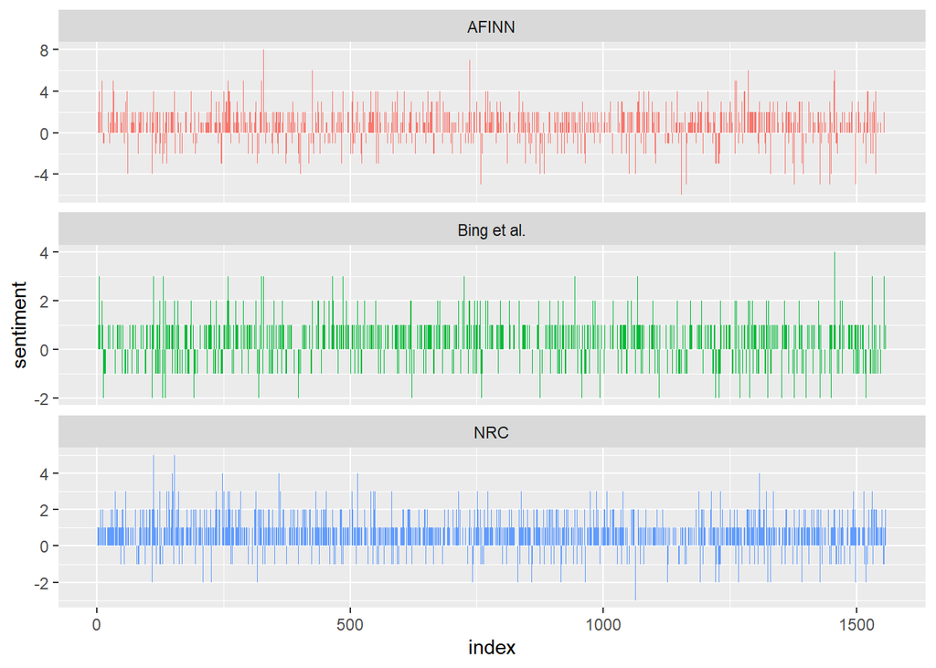

```r
bind_rows(afinn,
          bing_and_nrc) %>%
  ggplot(aes(index, sentiment, fill = method)) +
  geom_col(show.legend = FALSE) +
  facet_wrap(~method, ncol = 1, scales = "free_y")
```

```r
get_sentiments("nrc") %>%
  filter(sentiment %in% c("positive", "negative")) %>%
  count(sentiment)
```

```
## # A tibble: 2 × 2
##   sentiment     n
##   <chr>     <int>
## 1 negative   3316
## 2 positive   2308
```

```r
get_sentiments("bing") %>%
  count(sentiment)
```

```
## # A tibble: 2 × 2
##   sentiment     n
##   <chr>     <int>
## 1 negative   4781
## 2 positive   2005
```

```r
bing_word_counts <- tidy_newsm %>%
  inner_join(get_sentiments("bing")) %>%
  count(word, sentiment, sort = TRUE) %>%
  ungroup()
bing_word_counts
```

```
## # A tibble: 310 × 3
##    word         sentiment     n
##    <chr>        <chr>     <int>
##  1 cloud        negative     63
##  2 intelligence positive     52
##  3 improve      positive     32
##  4 top          positive     31
##  5 innovation   positive     23
##  6 autonomous   positive     19
##  7 better       positive     19
##  8 boost        positive     17
##  9 work         positive     17
## 10 bias         negative     16
## # … with 300 more rows
```

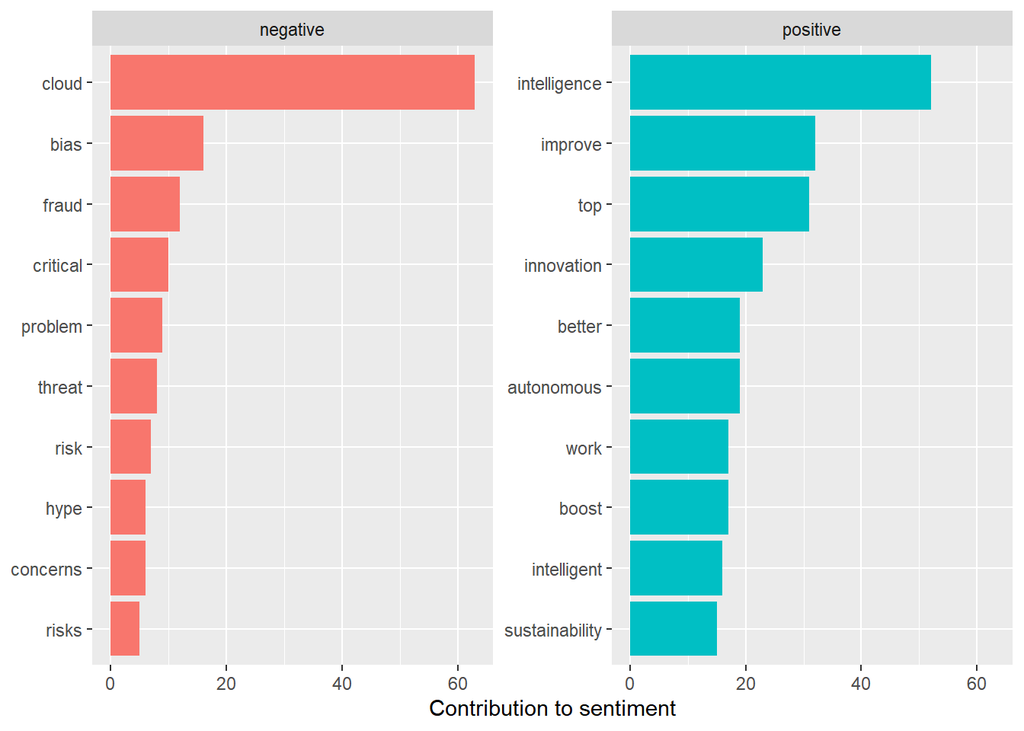

```r
bing_word_counts %>%
  group_by(sentiment) %>%
  slice_max(n, n = 10) %>%
  ungroup() %>%
  mutate(word = reorder(word, n)) %>%
  ggplot(aes(n, word, fill = sentiment)) +
  geom_col(show.legend = FALSE) +
  facet_wrap(~sentiment, scales = "free_y") +
  labs(x = "Contribution to sentiment",
       y = NULL)
```

```r
custom_stop_words <- bind_rows(tibble(word = c("cloud"),
                                      lexicon = c("custom")),
                               stop_words)

custom_stop_words
```

```
## # A tibble: 1,150 × 2
##    word        lexicon
##    <chr>       <chr>
##  1 cloud       custom
##  2 a           SMART
##  3 a's         SMART
##  4 able        SMART
##  5 about       SMART
##  6 above       SMART
##  7 according   SMART
##  8 accordingly SMART
##  9 across      SMART
## 10 actually    SMART
## # … with 1,140 more rows
```

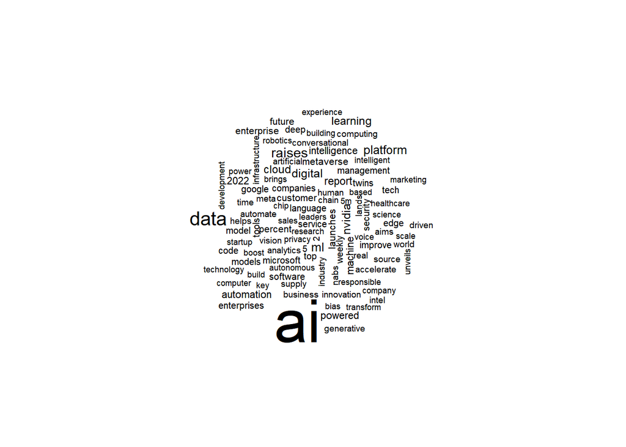

```r
library(wordcloud)
tidy_newsm %>%
  anti_join(stop_words) %>%
  count(word) %>%
  with(wordcloud(word, n, max.words = 100))
```

```r
library(reshape2)
```

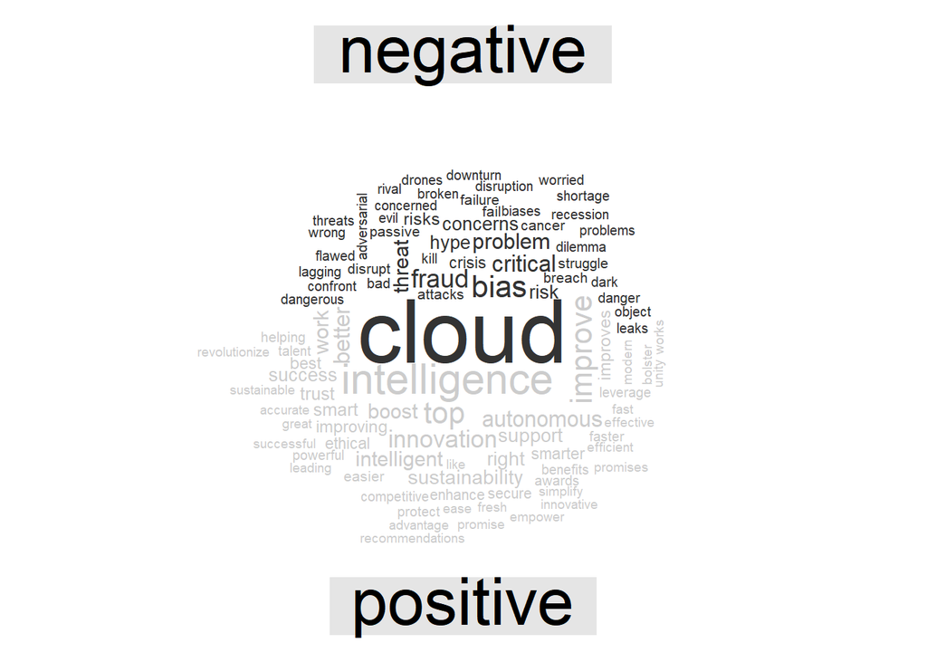

```r
tidy_newsm %>%
  inner_join(get_sentiments("bing")) %>%
  count(word, sentiment, sort = TRUE) %>%
  acast(word ~ sentiment, value.var = "n", fill = 0) %>%
  comparison.cloud(colors = c("gray20", "gray80"),
                   max.words = 100)
```